# Analyze Steamboat 4 mile Finisher data

- [Github page with source code for gathering data and performing analysis](https://github.com/mbromberek/race_finisher_analyze)

In 2019 the Steamboat 15K race changed from running up and down the Steamboat hills 2 times to 3 times. Want to determine if the change to the course resulted in faster or slower finisher times.

Have done these calcualtions using Average and Median. Both gave similar results with a larger difference using Median. Showing results with Average as I am more used to that statistic.

- Comparing finish times for each year by age groups
  - Finisher time for all runners by age group for each year
  - Finisher time for all runners by age group for 2 loop versus 3 loop course
  - Top 3 finishers time by age group for each year
  - Top 3 finishers time by age group for 2 loop versus 3 loop course
- Other factors that will affect finish times
  - Weather at start of race
  - Number of finishers

### Race Finisher Data

- Race data pulled from Athlinks for Steamboat race for years 2016, 2017, 2018, 2019, 2021, 2022, 2023.
- There was no race in 2020 and only a 4 mile race in 2021

### Weather Data

- Weather manually pulled from Carrot weather for 2016 through 2021
- Weather pulled from Apple WeatherKit for 2022 and 2023

### Use Age Groups of every 5 years

- Calculate average and median finish times for age groups

# Comparing Finish Times for each year by age groups

- Finishing time by age groups for each year
- Finishing time by age groups for 3 years of 2 hill loop course and 3 years of 3 hill loop course
- Finishing time for top 3 of each age groups for each year
- Finishing time for top 3 of each age groups for 3 years of 2 hill loop course and 3 years of 3 hill loop course

## Comparing average finish times by age group for each year

- dashed lines are for 3 loop course

Viewing each individual race can be hard to tell if finishers averaged faster or slower times based on the course change.

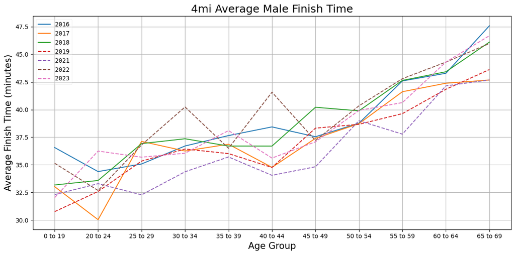

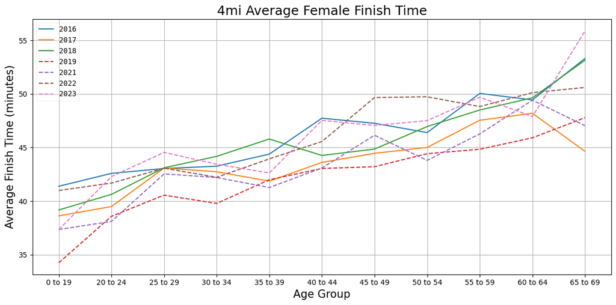

## Comparing average finish times for 2 versus 3 times up Steamboat Hill

Combine finishing times for 2016 through 2018 into “2 loop course” and 2019, 2022, and 2023 into “3 loop course” and get the average for those groups.

This indicates the new course is faster despite going up the Steamboat Hill 3 times instead of 2 times.

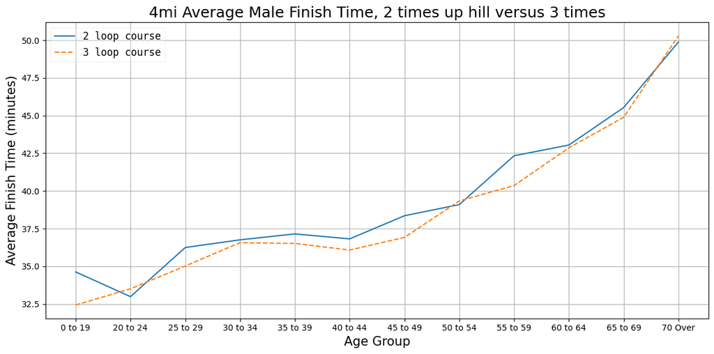

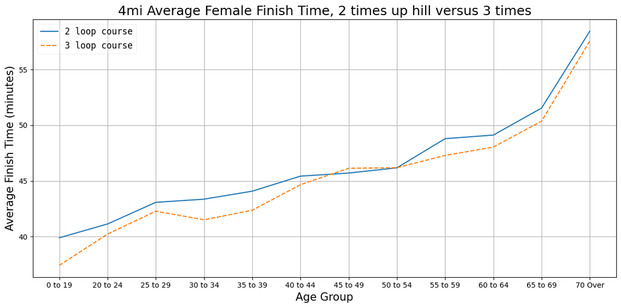

### Comparing the average pace in minutes per mile for the 2 loop versus 3 loop course

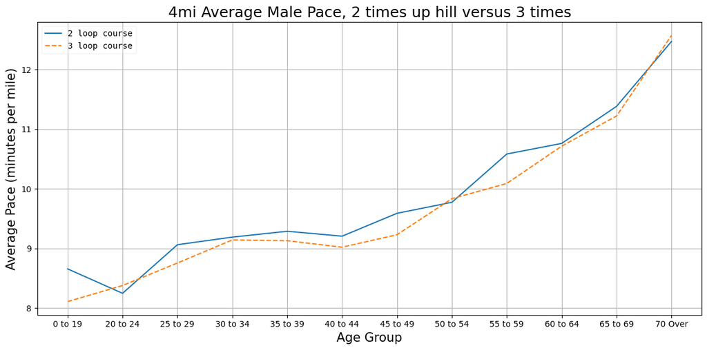

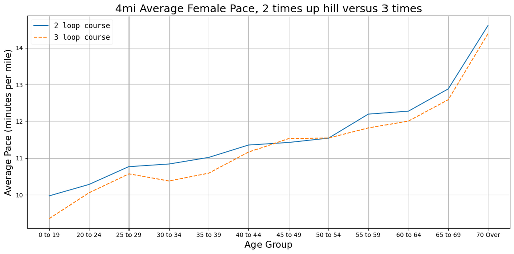

### Difference in average time between 3 loop and 2 courses

| Gender | Age Group | 2 Loop | 3 Loop | Time Delta | Pace Delta |
| --- | --- | --- | --- | --- | --- |
| F | 0 to 19 | 0:39:54 | 0:37:25 | 2:28 faster | 0:37/mile faster |
| F | 20 to 24 | 0:41:08 | 0:40:13 | 0:54 faster | 0:13/mile faster |
| F | 25 to 29 | 0:43:04 | 0:42:17 | 0:47 faster | 0:11/mile faster |
| F | 30 to 34 | 0:43:21 | 0:41:31 | 1:50 faster | 0:27/mile faster |
| F | 35 to 39 | 0:44:04 | 0:42:22 | 1:42 faster | 0:25/mile faster |
| F | 40 to 44 | 0:45:25 | 0:44:39 | 0:45 faster | 0:11/mile faster |
| F | 45 to 49 | 0:45:42 | 0:46:07 | 0:25 slower | 0:06/mile slower |
| F | 50 to 54 | 0:46:10 | 0:46:11 | 0:00 slower | 0:00/mile slower |
| F | 55 to 59 | 0:48:47 | 0:47:17 | 1:30 faster | 0:22/mile faster |
| F | 60 to 64 | 0:49:06 | 0:48:02 | 1:04 faster | 0:16/mile faster |
| F | 65 to 69 | 0:51:32 | 0:50:21 | 1:10 faster | 0:17/mile faster |
| F | 70 Over | 0:58:25 | 0:57:32 | 0:52 faster | 0:13/mile faster |
| M | 0 to 19 | 0:34:37 | 0:32:25 | 2:11 faster | 0:32/mile faster |
| M | 20 to 24 | 0:32:59 | 0:33:30 | 0:31 slower | 0:07/mile slower |
| M | 25 to 29 | 0:36:14 | 0:35:01 | 1:13 faster | 0:18/mile faster |
| M | 30 to 34 | 0:36:45 | 0:36:34 | 0:11 faster | 0:02/mile faster |
| M | 35 to 39 | 0:37:08 | 0:36:30 | 0:38 faster | 0:09/mile faster |
| M | 40 to 44 | 0:36:49 | 0:36:04 | 0:44 faster | 0:11/mile faster |
| M | 45 to 49 | 0:38:21 | 0:36:55 | 1:26 faster | 0:21/mile faster |
| M | 50 to 54 | 0:39:05 | 0:39:20 | 0:14 slower | 0:03/mile slower |
| M | 55 to 59 | 0:42:20 | 0:40:21 | 1:58 faster | 0:29/mile faster |
| M | 60 to 64 | 0:43:02 | 0:42:51 | 0:10 faster | 0:02/mile faster |
| M | 65 to 69 | 0:45:32 | 0:44:53 | 0:38 faster | 0:09/mile faster |
| M | 70 Over | 0:49:53 | 0:50:17 | 0:24 slower | 0:06/mile slower |

| Gender | Average Pace Delta |
| --- | --- |
| F | 0:15/mile |
| M | 0:10/mile |

## Finish times of top three by age group for each year

Using the top 3 finishers for each age group the average finish time for men and women is much closer indicating the top 3 finishers for each age group was not significantly impacted by the course change.

Use Average as the outliers are being removed since only looking at top 3 finishers

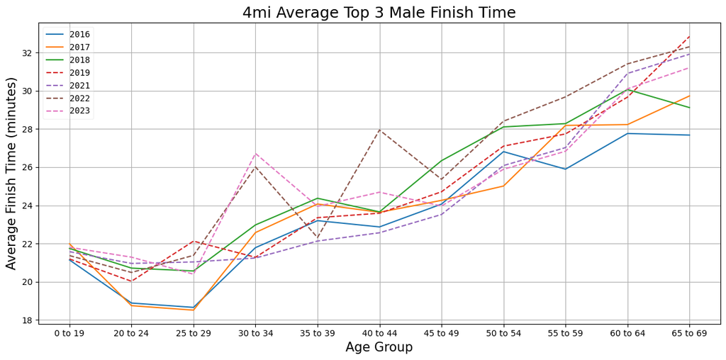

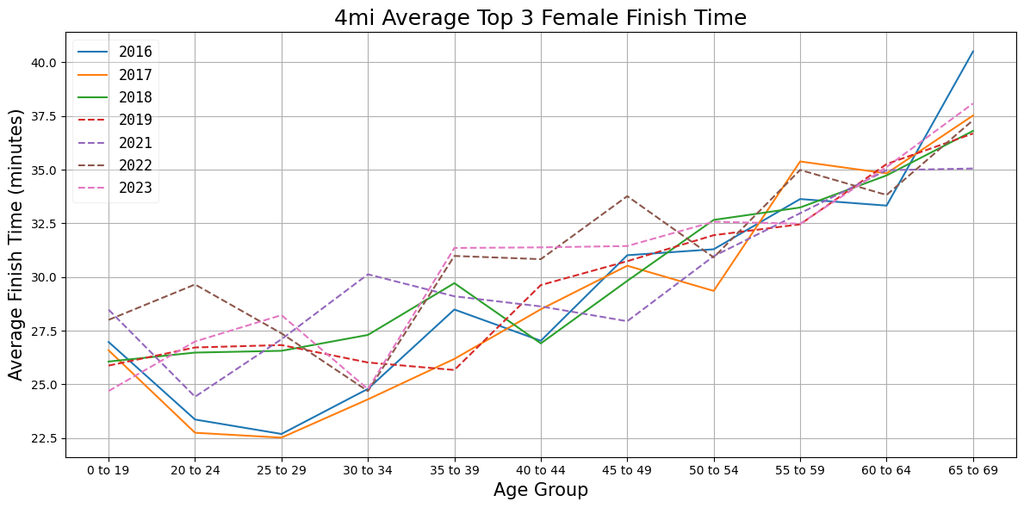

## Top three by age group for 2 versus 3 times up Steamboat Hill

Do not see much difference in age groups when grouping the races by the different course layouts.

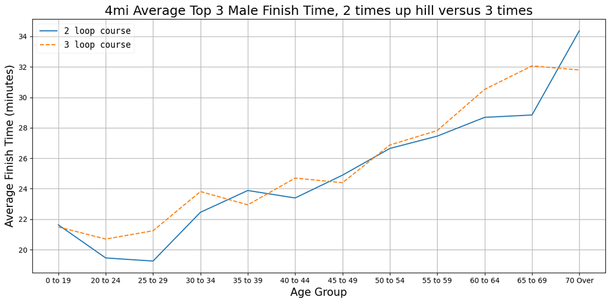

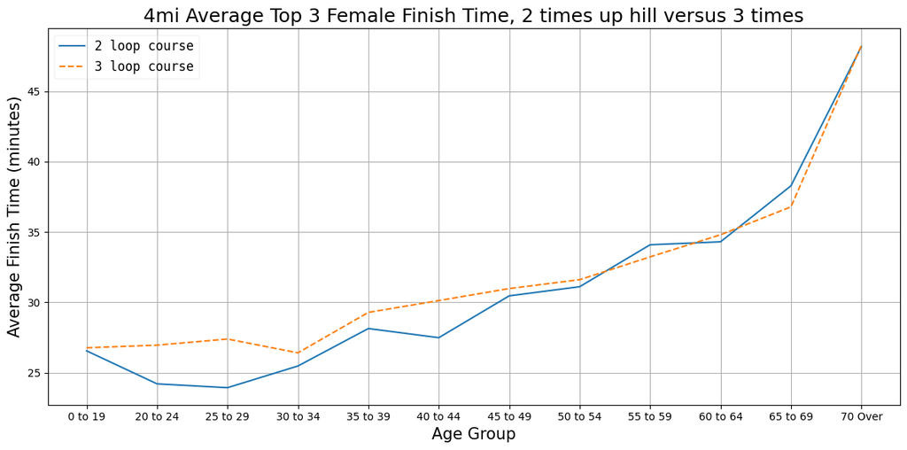

| Gender | Age Group | 2 Loop | 3 Loop | Time Delta | Pace Delta |
| --- | --- | --- | --- | --- | --- |
| F | 0 to 19 | 0:26:32 | 0:26:45 | 0:13 slower | 0:03/mile slower |
| F | 20 to 24 | 0:24:12 | 0:26:57 | 2:45 slower | 0:41/mile slower |
| F | 25 to 29 | 0:23:55 | 0:27:23 | 3:27 slower | 0:51/mile slower |
| F | 30 to 34 | 0:25:28 | 0:26:24 | 0:56 slower | 0:14/mile slower |
| F | 35 to 39 | 0:28:07 | 0:29:16 | 1:08 slower | 0:17/mile slower |
| F | 40 to 44 | 0:27:28 | 0:30:07 | 2:38 slower | 0:39/mile slower |
| F | 45 to 49 | 0:30:27 | 0:30:58 | 0:31 slower | 0:07/mile slower |
| F | 50 to 54 | 0:31:06 | 0:31:36 | 0:30 slower | 0:07/mile slower |
| F | 55 to 59 | 0:34:05 | 0:33:13 | 0:51 faster | 0:12/mile faster |
| F | 60 to 64 | 0:34:17 | 0:34:47 | 0:29 slower | 0:07/mile slower |
| F | 65 to 69 | 0:38:16 | 0:36:46 | 1:29 faster | 0:22/mile faster |
| F | 70 Over | 0:48:10 | 0:48:14 | 0:04 slower | 0:01/mile slower |
| M | 0 to 19 | 0:21:37 | 0:21:29 | 0:08 faster | 0:02/mile faster |
| M | 20 to 24 | 0:19:27 | 0:20:41 | 1:14 slower | 0:18/mile slower |
| M | 25 to 29 | 0:19:14 | 0:21:14 | 1:59 slower | 0:29/mile slower |
| M | 30 to 34 | 0:22:26 | 0:23:48 | 1:21 slower | 0:20/mile slower |
| M | 35 to 39 | 0:23:52 | 0:22:56 | 0:56 faster | 0:14/mile faster |
| M | 40 to 44 | 0:23:23 | 0:24:41 | 1:18 slower | 0:19/mile slower |
| M | 45 to 49 | 0:24:53 | 0:24:23 | 0:29 faster | 0:07/mile faster |
| M | 50 to 54 | 0:26:38 | 0:26:52 | 0:13 slower | 0:03/mile slower |
| M | 55 to 59 | 0:27:27 | 0:27:49 | 0:21 slower | 0:05/mile slower |
| M | 60 to 64 | 0:28:41 | 0:30:31 | 1:50 slower | 0:27/mile slower |
| M | 65 to 69 | 0:28:50 | 0:32:03 | 3:13 slower | 0:48/mile slower |
| M | 70 Over | 0:34:22 | 0:31:47 | 2:34 faster | 0:38/mile faster |

The Average Age Group pace change for 2 loop versus 3 for males and females for top 3 finishers is not very large. The Average is lower than the average improvement for any age groups that got faster for male or females.

| Gender | Average Pace Delta |
| --- | --- |
| F | 0:12/mile |
| M | 0:09/mile |

# Other factors that will affect finisher times

- The starting temperature for the race was better for each of the years that had the 3 loops of the Steamboat Hill when compared to the 2 loop years. The improved weather could be causing the improved performance instead of the change to the course.
- The number of finishers for the 15K are lower with the 3 loop course compared to the 2 loop course. So could have less slower runners resulting in the different average finishing times.

## Weather at start of race

|  | Temperature | Feels Like | Dew Point | Cloud Cover |
| --- | --- | --- | --- | --- |
| 2016 | 68.00 | 67.00 | 57.00 | 22.00 |
| 2017 | 72.00 | 78.00 | 69.00 | 51.00 |
| 2018 | 75.00 | 80.00 | 70.00 | 1.00 |
| 2019 | 64.00 | 63.00 | 60.00 | 85.00 |
| 2021 | 73.00 | 76.00 | 71.00 | 28.00 |
| 2022 | 65.05 | 64.40 | 53.08 | 0.00 |
| 2023 | 57.36 | 56.79 | 52.95 | 0.02 |

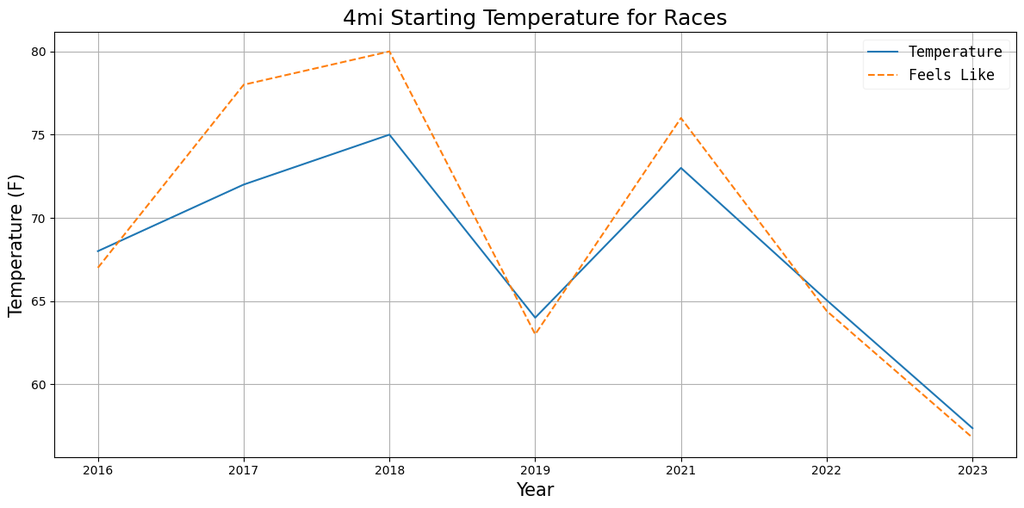

## Number of Finishers

### Number of finishers in age groups

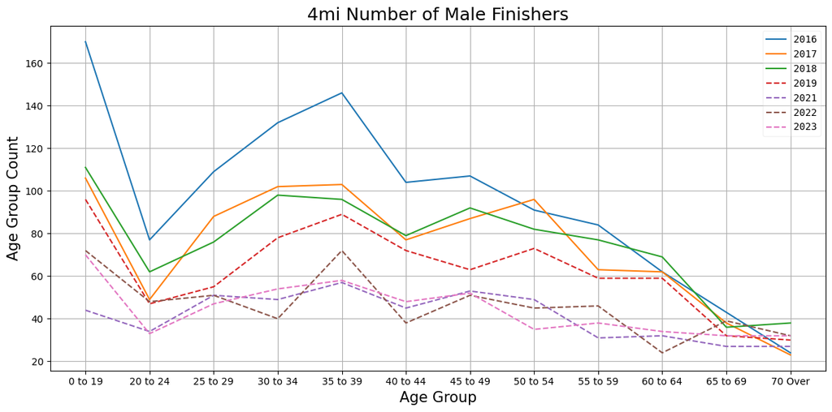

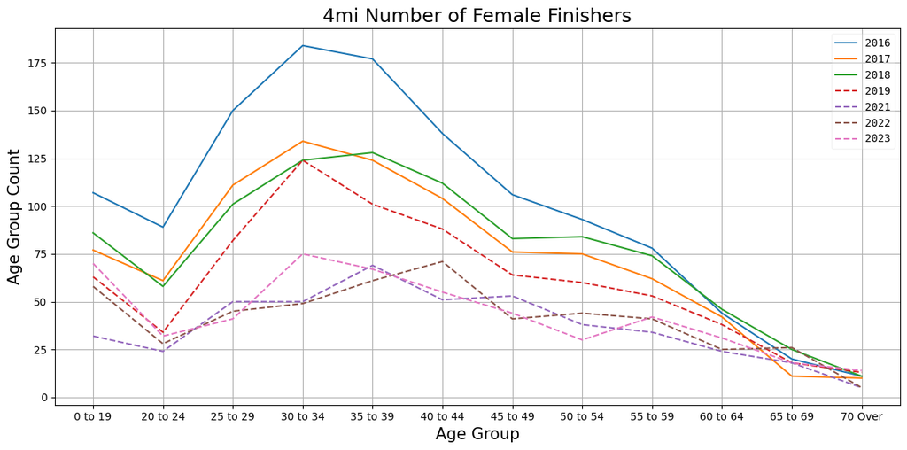

### Total number of male and female finishers by year

| year | gender | finisher_count |
| --- | --- | --- |
| 2016 | F | 1197 |
| 2016 | M | 1149 |
| 2016 | U | 0 |
| 2017 | F | 887 |
| 2017 | M | 894 |
| 2017 | U | 0 |
| 2018 | F | 932 |
| 2018 | M | 916 |
| 2018 | U | 0 |
| 2019 | F | 738 |
| 2019 | M | 753 |
| 2019 | U | 0 |
| 2021 | F | 448 |
| 2021 | M | 499 |
| 2021 | U | 1 |
| 2022 | F | 494 |
| 2022 | M | 558 |
| 2022 | U | 0 |
| 2023 | F | 519 |
| 2023 | M | 533 |
| 2023 | U | 0 |

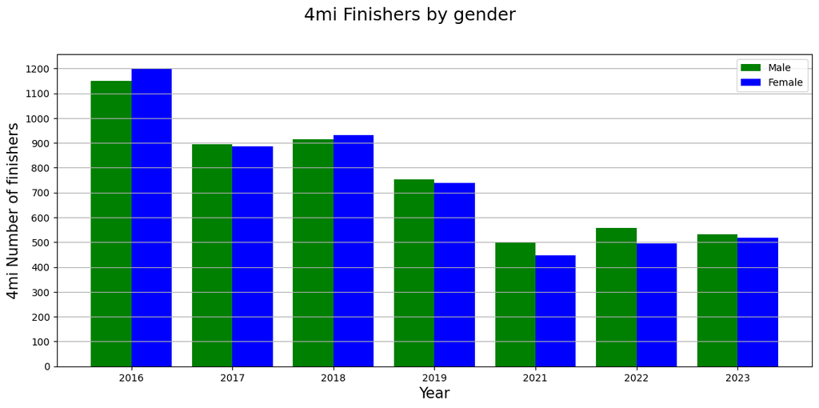